# Lesson 3

### References

1. https://flowingdata.com/2014/02/27/how-to-read-histograms-and-use-them-in-r/
2. https://github.com/jrnold/ggthemes#examples
3. http://www.cookbook-r.com/Graphs/Facets_(ggplot2)/
4. https://en.wikipedia.org/wiki/Top-coded
5. http://ggplot2.tidyverse.org/reference/scale_continuous.html
6. https://www.statmethods.net/input/missingdata.html
7. http://ggplot2.tidyverse.org/reference/theme.html

### What to Do First?

Notes: Create a histogram of the data for the initial analysis. ***

```r
getwd()
```

```
## [1] "/Users/stevetan/Dropbox/0udacity/data analyst nanodegree/eda"
```

```r
list.files()
```

```
##  [1] "What_is_a_RMD_file.html" "What_is_a_RMD_file.rmd"
##  [3] "demystifying.r"          "demystifyingr2-v3.rmd"
##  [5] "lesson3_exercise.rmd"    "lesson3_student.rmd"
##  [7] "priceColorBoxplot.png"   "priceCutBoxplot.png"
##  [9] "priceGap.png"            "priceHistogram.png"
## [11] "priceMax.png"            "pseudo_facebook.tsv"
## [13] "rbasics.Rmd"             "rbasics.nb.html"
## [15] "reddit.csv"              "stateData.csv"
```

```r
pf <- read.csv("pseudo_facebook.tsv", sep='\t')
names(pf)
```

```
##  [1] "userid"                "age"
##  [3] "dob_day"               "dob_year"
##  [5] "dob_month"             "gender"
##  [7] "tenure"                "friend_count"
##  [9] "friendships_initiated" "likes"
## [11] "likes_received"        "mobile_likes"
## [13] "mobile_likes_received" "www_likes"
## [15] "www_likes_received"
```

### Pseudo-Facebook User Data

Notes:

```r
#install.packages('ggthemes', dependencies = TRUE)
library(ggthemes)
```

### Histogram of Users’ Birthdays

Notes:

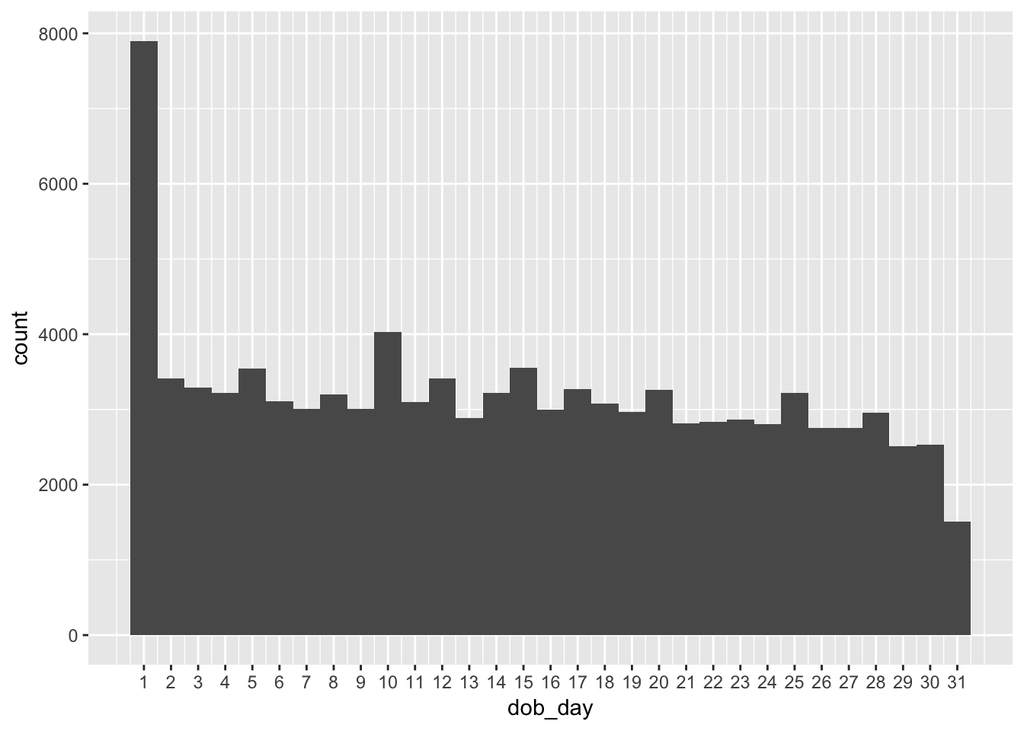

```r
#install.packages('ggplot2')
library(ggplot2)
ggplot(aes(x = dob_day), data = pf) +
  geom_histogram(binwidth = 1) +
  scale_x_continuous(breaks = 1:31)
```

#### What are some things that you notice about this histogram?

Response: The 1st day of the month have an unusual higher number of user counts, whereas the last day of the month has a lower number of users count due to the fact not every month has a 31st. ***

### Moira’s Investigation

Notes:

### Estimating Your Audience Size

Notes:

#### Think about a time when you posted a specific message or shared a photo on Facebook. What was it?

Response:

#### How many of your friends do you think saw that post?

Response: 20 views from friends

#### Think about what percent of your friends on Facebook see any posts or comments that you make in a month. What percent do you think that is?

Response: 5% ***

### Perceived Audience Size

Notes:

### Faceting

Notes:

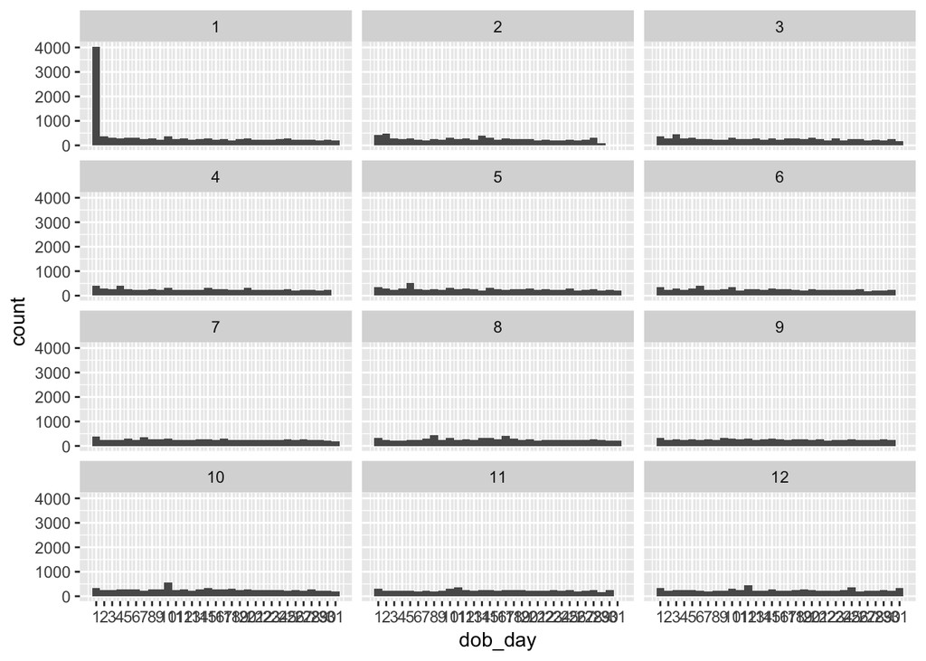

```r
ggplot(data = pf, aes(x = dob_day)) +
  geom_histogram(binwidth = 1) +
  scale_x_continuous(breaks = 1:31) +
  facet_wrap(~dob_month, ncol = 3)
```

#### Let???s take another look at our plot. What stands out to you here?

Response:

### Be Skeptical - Outliers and Anomalies

Notes:

### Moira’s Outlier

Notes: #### Which case do you think applies to Moira???s outlier? Response:

### Friend Count

Notes:

#### What code would you enter to create a histogram of friend counts?

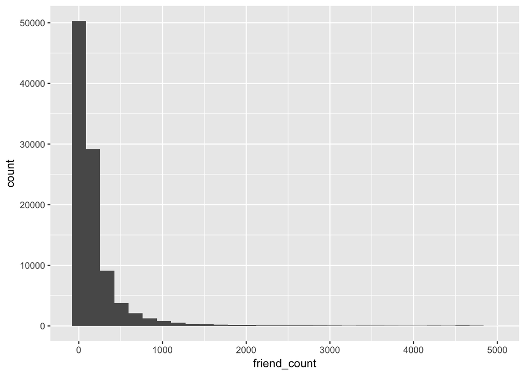

```r
ggplot(aes(x = friend_count), data = pf) +
  geom_histogram()
```

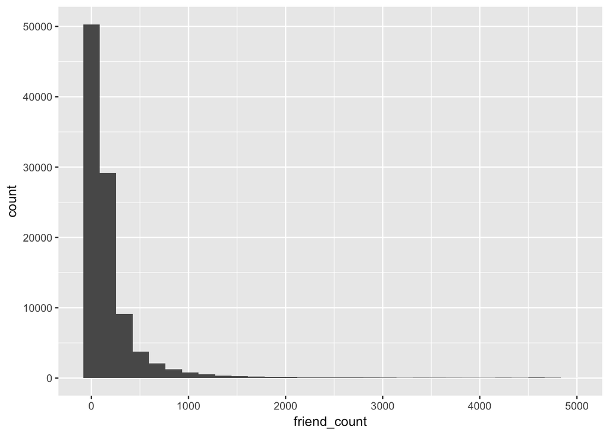

```r
qplot(data=pf, x= friend_count)
```

#### How is this plot similar to Moira’s first plot?

Response:

### Limiting the Axes

Notes:

```r
qplot(data=pf, x=friend_count, xlim= c(0,1000))
qplot(data=pf, x=friend_count) +
    scale_x_continuous(limits = c(0,1000))
ggplot(aes(x = friend_count), data = pf) +
  geom_histogram() +
  scale_x_continuous(limits = c(0, 1000))
```

[output not shown]

### Exploring with Bin Width

Notes:

### Adjusting the Bin Width

Notes:

### Faceting Friend Count

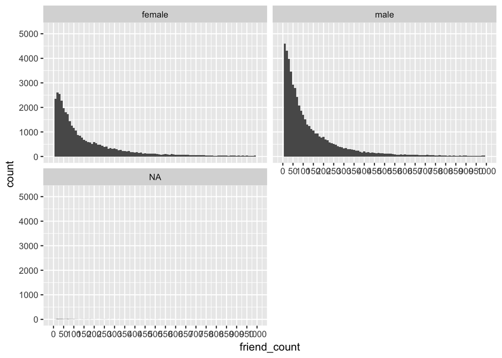

```r
# What code would you add to create a facet the histogram by gender?
# Add it to the code below.
qplot(x = friend_count, data = pf, binwidth = 10) +
  scale_x_continuous(limits = c(0, 1000),
                     breaks = seq(0, 1000, 50)) +
  facet_wrap(~gender, ncol=2)
```

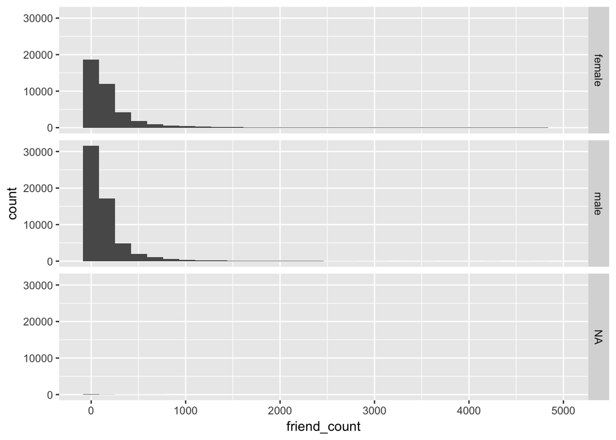

```r
qplot(x = friend_count, data = pf) +
  facet_grid(gender ~ .)
```

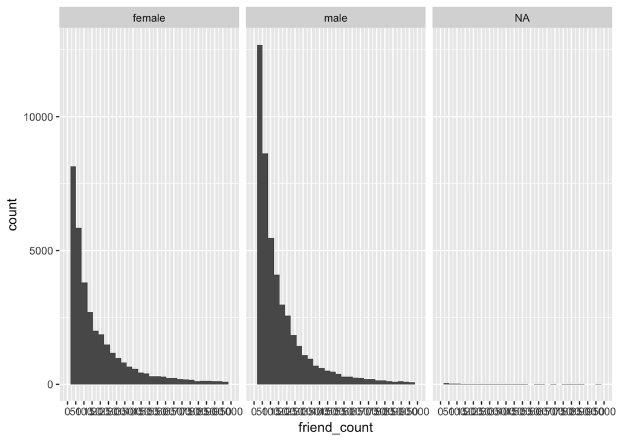

```r
ggplot(aes(x = friend_count), data = pf) +
  geom_histogram() +
  scale_x_continuous(limits = c(0, 1000), breaks = seq(0, 1000, 50)) +
  facet_wrap(~gender)
```

### Omitting NA Values

Notes:

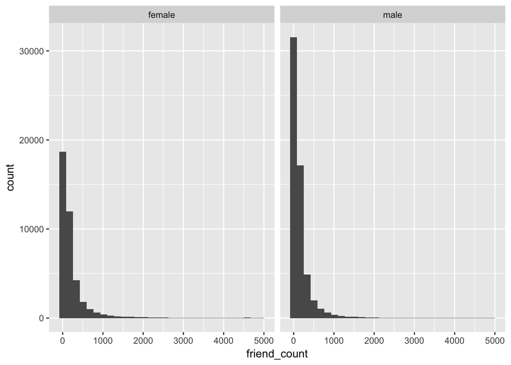

```r
qplot(x = friend_count, data = subset(pf,!is.na(pf$gender))) +
  facet_wrap(~gender)
```

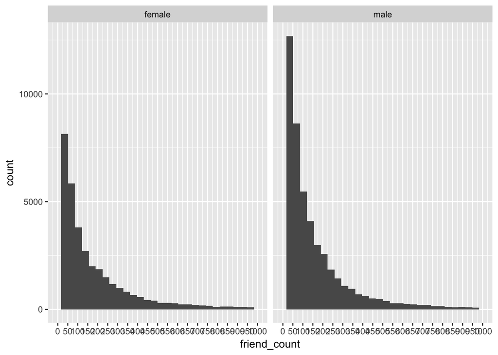

```r
ggplot(aes(x = friend_count), data = subset(pf,!is.na(pf$gender))) +
  geom_histogram() +
  scale_x_continuous(limits = c(0, 1000), breaks = seq(0, 1000, 50)) +
  facet_wrap(~gender)
```

### Statistics ‘by’ Gender

Notes:

```r
table(pf$gender)
```

```
##
## female   male
##  40254  58574
```

```r
by(pf$friend_count, pf$gender, summary)
```

```
## pf$gender: female
##    Min. 1st Qu.  Median    Mean 3rd Qu.    Max.
##       0      37      96     242     244    4923
## --------------------------------------------------------
## pf$gender: male
##    Min. 1st Qu.  Median    Mean 3rd Qu.    Max.
##       0      27      74     165     182    4917
```

#### Who on average has more friends: men or women?

Response: women

#### What’s the difference between the median friend count for women and men?

Response: 22

#### Why would the median be a better measure than the mean?

Response: not affected by the outlier value which in this dataset is a very larger number.

### Tenure

Notes:

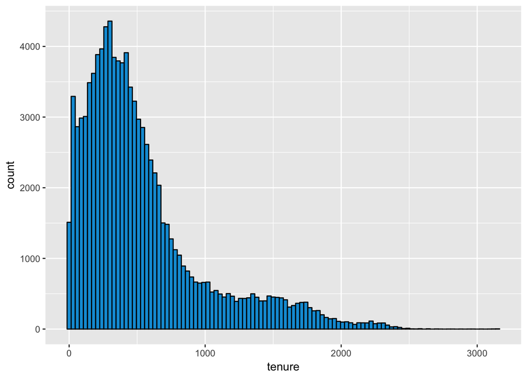

```r
qplot(data=pf, x = tenure, color=I('black'), fill=I('#099DD9'), binwidth=30)
```

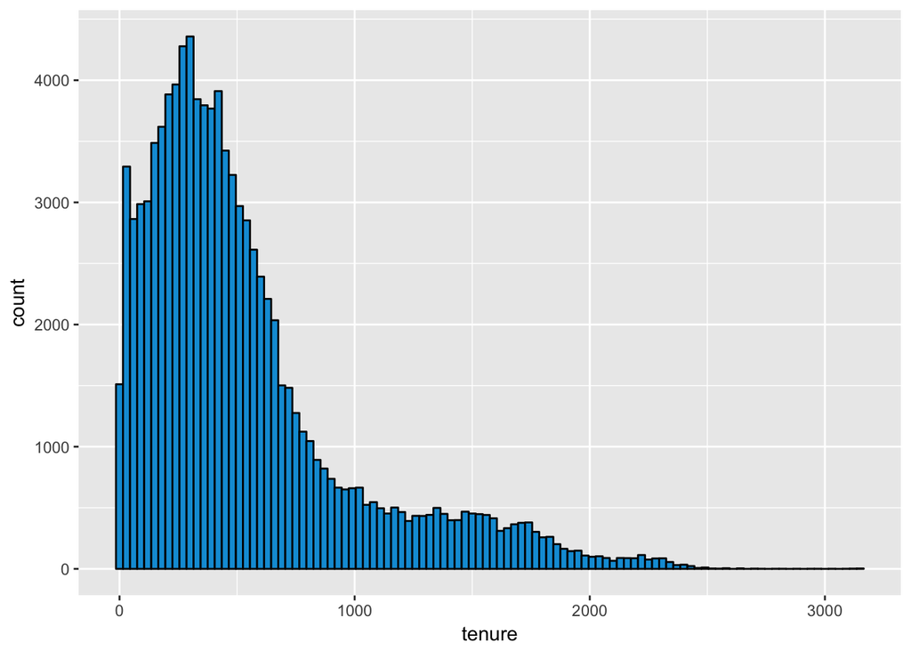

```r
ggplot(aes(x = tenure), data = pf) +
  geom_histogram(binwidth = 30, color = 'black', fill = '#099DD9')
```

#### How would you create a histogram of tenure by year?

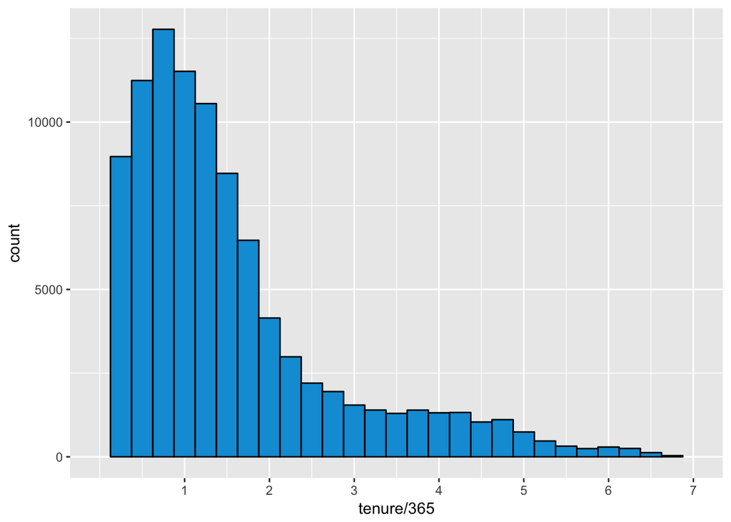

```r
qplot(data=pf, x = tenure/365, color=I('black'), fill=I('#099DD9'), binwidth=.25) +
 scale_x_continuous(breaks=seq(1,7,1), limits=c(0, 7))
```

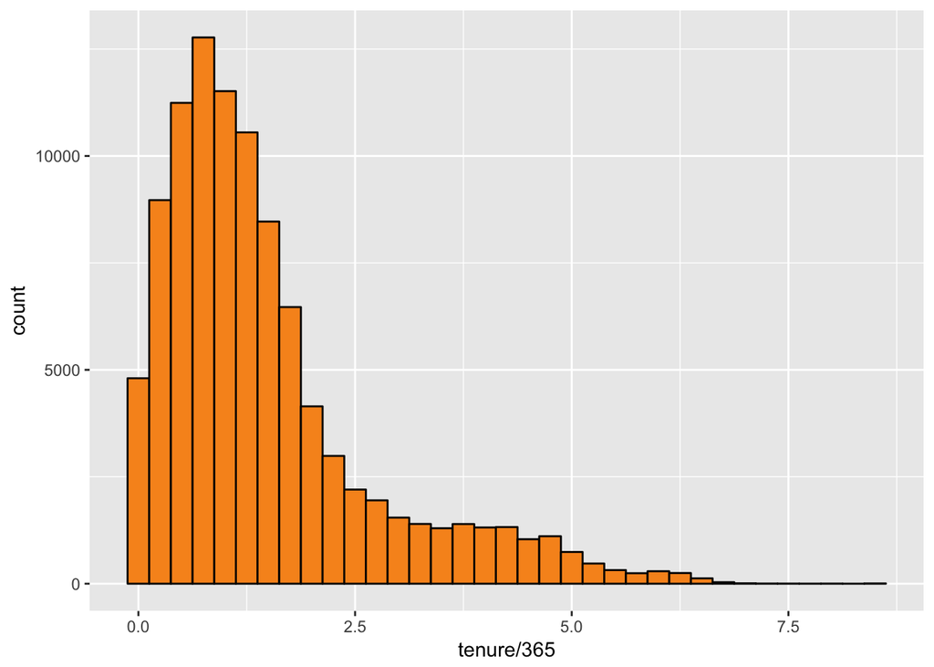

```r
ggplot(aes(x = tenure/365), data = pf) +
  geom_histogram(binwidth = .25, color = 'black', fill = '#F79420')
```

### Labeling Plots

Notes:

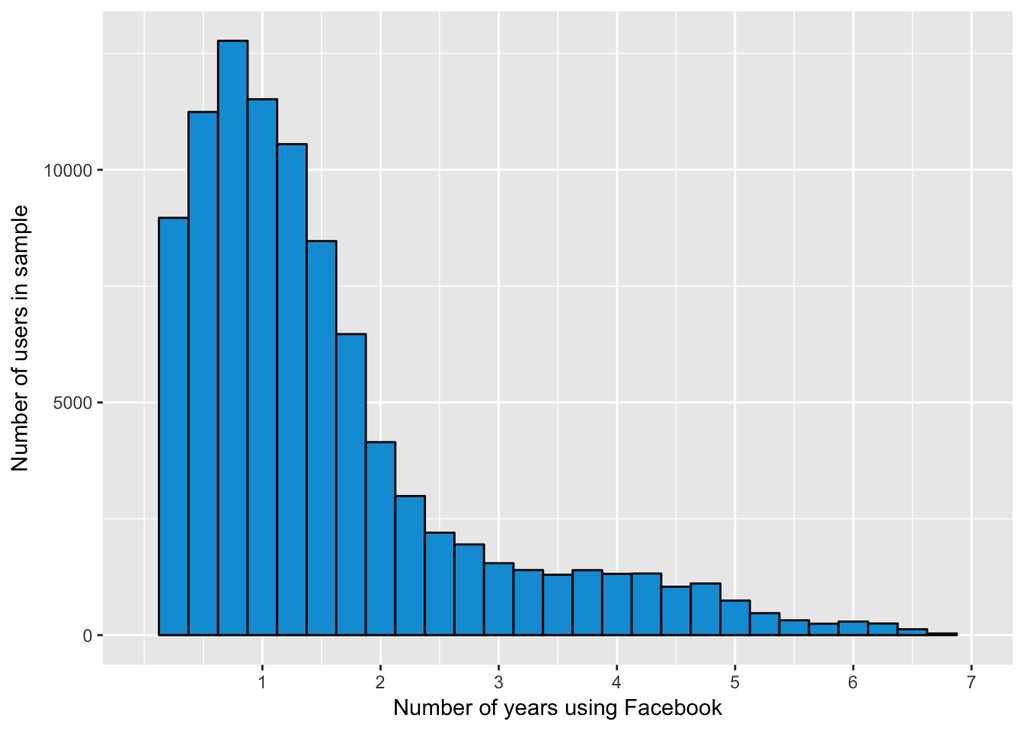

```r
qplot(data=pf, x = tenure/365, color=I('black'), fill=I('#099DD9'), binwidth=.25,
      xlab="Number of years using Facebook", ylab="Number of users in sample") +
 scale_x_continuous(breaks=seq(1,7,1), limits=c(0, 7))
```

### User Ages

Notes:

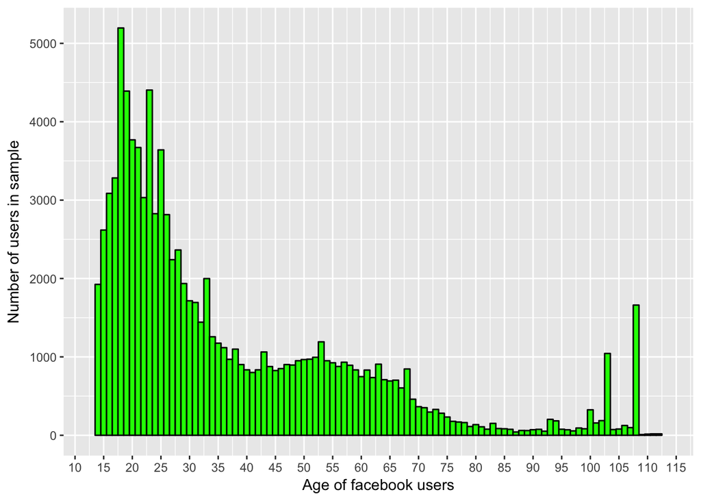

```r
qplot(data=pf, x=age, color=I('black'), fill=I('green'), binwidth=1,
      xlab="Age of facebook users", ylab="Number of users in sample") +
    scale_x_continuous(breaks=seq(0,115, 5), limits=c(13,113))
```

```r
summary(pf$age)
```

```
##    Min. 1st Qu.  Median    Mean 3rd Qu.    Max.
##   13.00   20.00   28.00   37.28   50.00  113.00
```

### The Spread of Memes

Notes:

### Lada’s Money Bag Meme

Notes:

### Transforming Data

Notes:

### Add a Scaling Layer

Notes: 1. https://www.r-statistics.com/2013/05/log-transformations-for-skewed-and-wide-distributions-from-practical-data-science-with-r/ 1. https://en.wikipedia.org/wiki/Normal_distribution 1. https://en.wikipedia.org/wiki/Linear_regression#Assumptions 1. http://lightonphiri.org/blog/ggplot2-multiple-plots-in-one-graph-using-gridextra 1. https://www.r-statistics.com/2013/05/log-transformations-for-skewed-and-wide-distributions-from-practical-data-science-with-r/

```r
p1 = qplot(data=pf, x=pf$friend_count, color=I('black'), fill=I('#099DD9'),
      xlab="Number of friends per Facebook user", ylab="Number of users in sample")

summary(pf$friend_count)
```

```
##    Min. 1st Qu.  Median    Mean 3rd Qu.    Max.
##     0.0    31.0    82.0   196.4   206.0  4923.0
```

```r
summary (log10(pf$friend_count + 1))
```

```
##    Min. 1st Qu.  Median    Mean 3rd Qu.    Max.
##   0.000   1.505   1.919   1.868   2.316   3.692
```

```r
summary (sqrt(pf$friend_count))
```

```
##    Min. 1st Qu.  Median    Mean 3rd Qu.    Max.
##   0.000   5.568   9.055  11.090  14.350  70.160
```

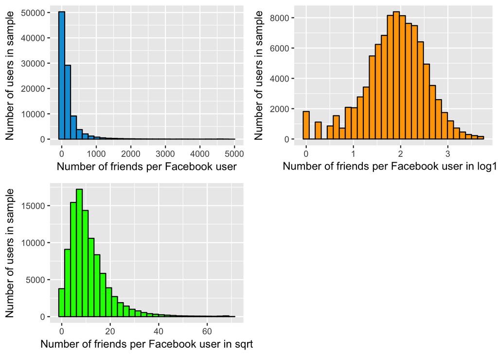

```r
#install.packages('gridExtra')
library(gridExtra)

p2 = qplot(data=pf, x=log10(pf$friend_count), color=I('black'), fill=I('orange'),
      xlab="Number of friends per Facebook user in log10", ylab="Number of users in sample")

p3 = qplot(data=pf, x=sqrt(pf$friend_count), color=I('black'), fill=I('green'),
      xlab="Number of friends per Facebook user in sqrt", ylab="Number of users in sample")

grid.arrange(p1,p2,p3, ncol=2)
```

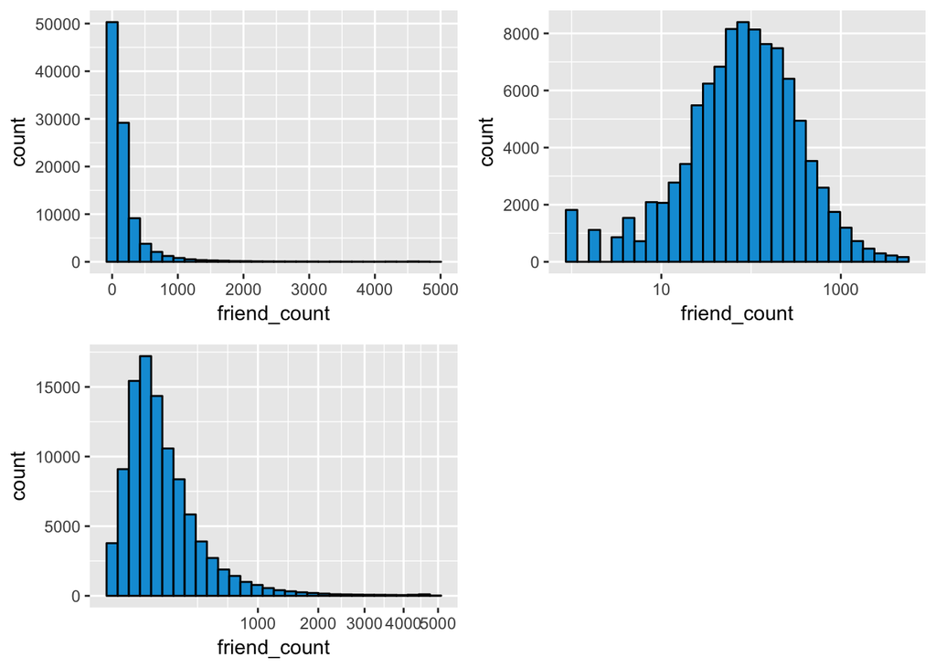

```r
p1 = ggplot(data=pf, aes(x=friend_count)) + geom_histogram(color=I('black'), fill=I('#099DD9'))

p2 = p1 + scale_x_log10()

p3 = p1 + scale_x_sqrt()

grid.arrange(p1,p2,p3, ncol=2)
```

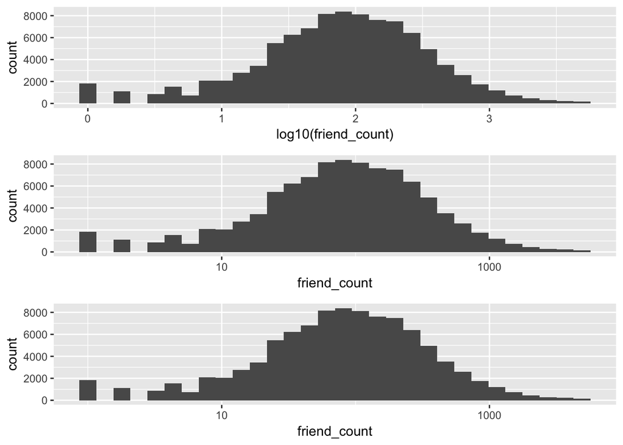

```r
logScale <- qplot(data=pf, x=log10(friend_count))
countScale <- ggplot(aes(x=friend_count), data=pf) + geom_histogram() + scale_x_log10()
logScale2 <- qplot(data=pf, x=friend_count) + scale_x_log10()
grid.arrange(logScale, countScale, logScale2)
```

### Frequency Polygons

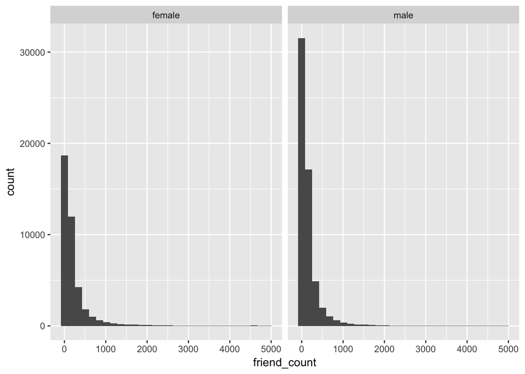

```r
qplot(x = friend_count, data = subset(pf,!is.na(pf$gender))) +
  facet_wrap(~gender)
```

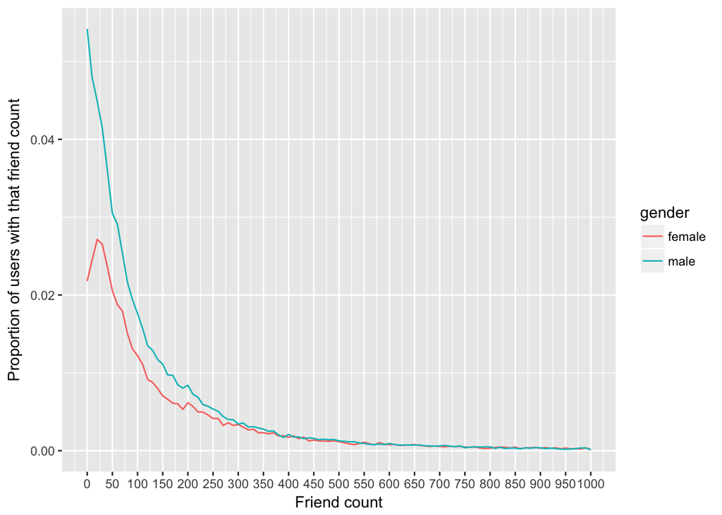

```r
qplot(x = friend_count, y = ..count../sum(..count..),
      data = subset(pf,!is.na(pf$gender)), binwidth=10, color=gender, geom='freqpoly',
      xlab="Friend count", ylab="Proportion of users with that friend count") +
    scale_x_continuous(limits = c(0,1000), breaks= seq(0,1000,50))
```

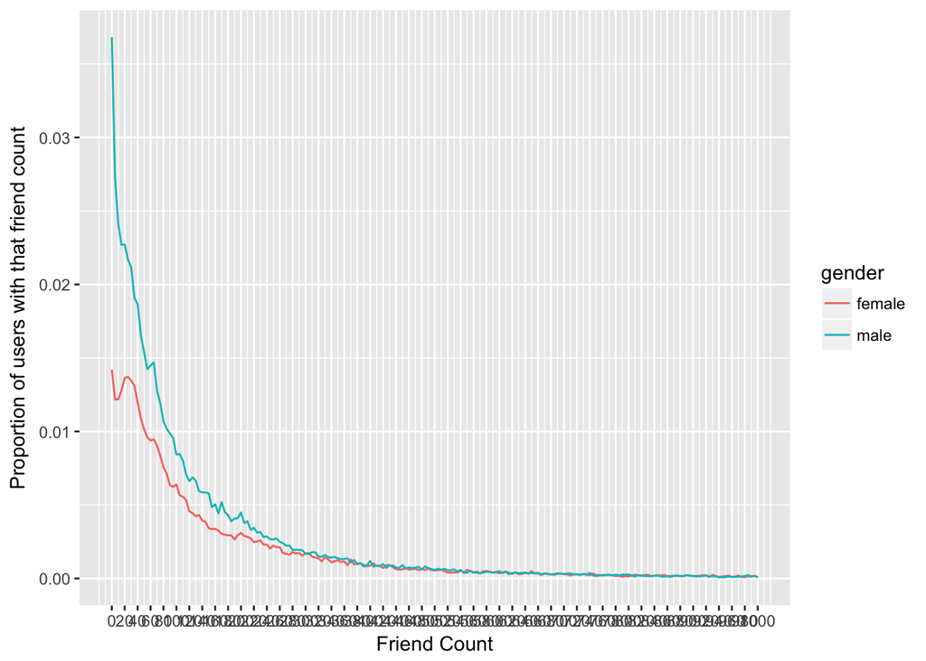

```r
ggplot(aes(x = friend_count, y = ..count../sum(..count..)),
       data = subset(pf, !is.na(gender))) +
  geom_freqpoly(aes(color = gender), binwidth=5) +
  scale_x_continuous(limits = c(0, 1000), breaks = seq(0, 1000, 20)) +
  xlab('Friend Count') +
  ylab('Proportion of users with that friend count')
```

### Likes on the Web

Notes:

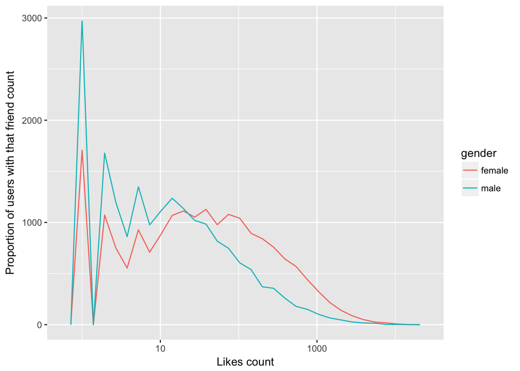

```r
qplot(x = www_likes,
      data = subset(pf,!is.na(pf$gender)), color=gender, geom='freqpoly',
      xlab="Likes count", ylab="Proportion of users with that friend count") +
    scale_x_log10()
```

```r
summary(pf$www_likes)
```

```
##     Min.  1st Qu.   Median     Mean  3rd Qu.     Max.
##     0.00     0.00     0.00    49.96     7.00 14860.00
```

```r
by(pf$www_likes, pf$gender, sum)
```

```
## pf$gender: female
## [1] 3507665
## --------------------------------------------------------
## pf$gender: male
## [1] 1430175
```

### Box Plots

Notes:

1. https://flowingdata.com/2008/02/15/how-to-read-and-use-a-box-and-whisker-plot/
2. https://en.wikipedia.org/wiki/Interquartile_range
3. https://en.wikipedia.org/wiki/File:Boxplot_vs_PDF.svg

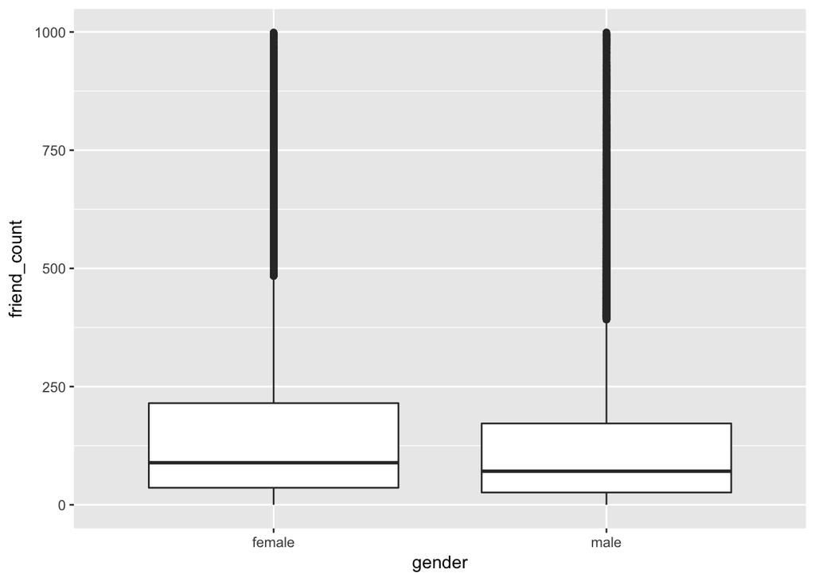

```r
qplot(data= subset(pf,!is.na(gender) & friend_count < 1000),
                   x=gender, y=friend_count, geom='boxplot')
```

#### Adjust the code to focus on users who have friend counts between 0 and 1000.

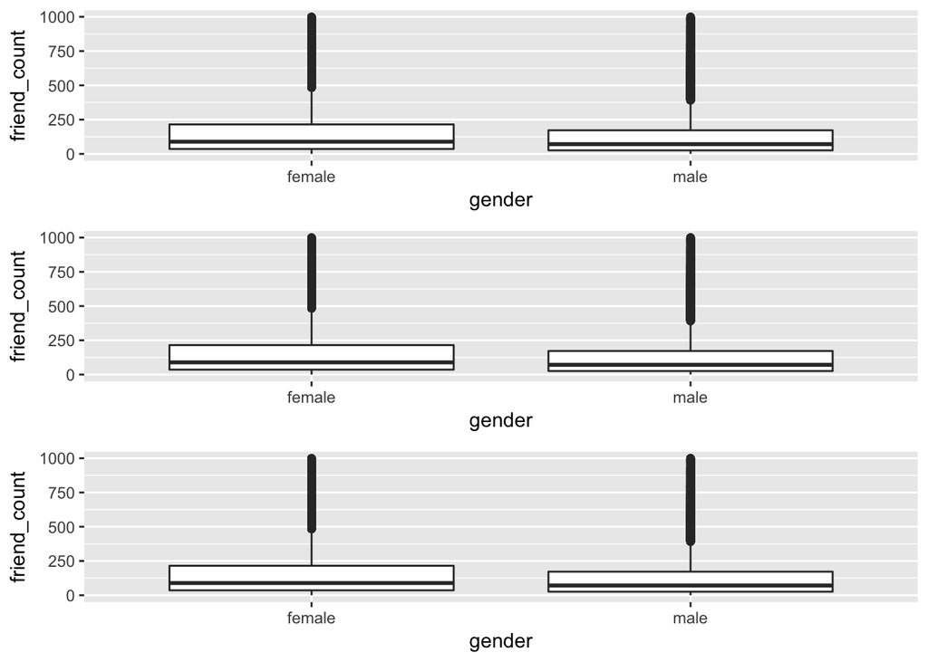

```r
box1 <- qplot(data= subset(pf,!is.na(gender) & friend_count < 1000),
                   x=gender, y=friend_count, geom='boxplot')

box2 <- qplot(data= subset(pf,!is.na(gender)),
                   x=gender, y=friend_count, geom='boxplot', ylim=c(0,1000))

box3 <- qplot(data= subset(pf,!is.na(gender)),
                   x=gender, y=friend_count, geom='boxplot') +
    scale_y_continuous(limits = c(0,1000))

grid.arrange(box1, box2, box3)
```

### Box Plots, Quartiles, and Friendships

Notes:

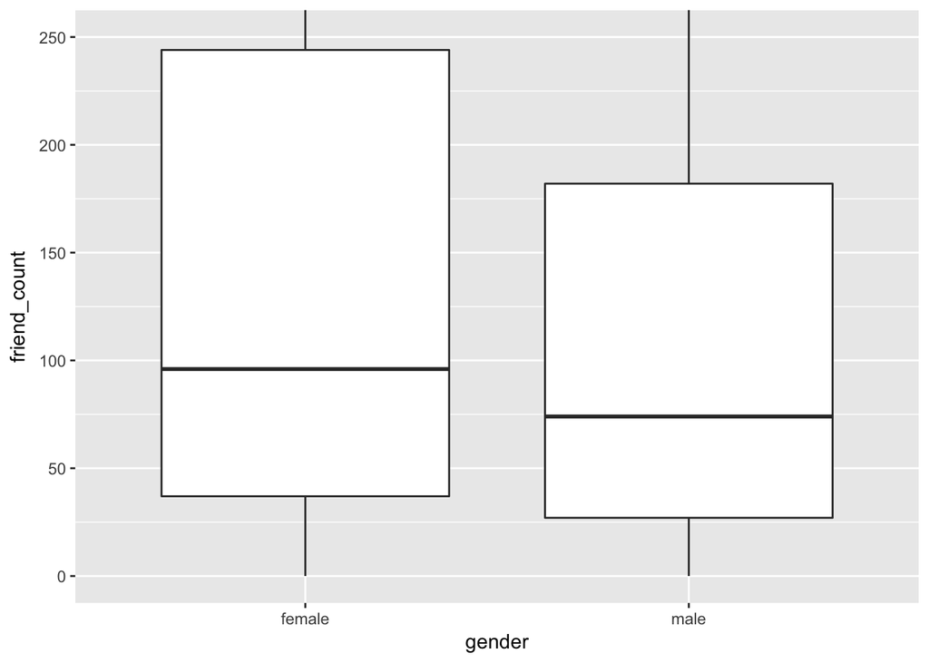

```r
qplot(data= subset(pf,!is.na(gender)),
                   x=gender, y=friend_count, geom='boxplot') +
    coord_cartesian(ylim = c(0,250))
```

```r
by(pf$friend_count, pf$gender, summary)
```

```
## pf$gender: female
##    Min. 1st Qu.  Median    Mean 3rd Qu.    Max.
##       0      37      96     242     244    4923
## --------------------------------------------------------
## pf$gender: male
##    Min. 1st Qu.  Median    Mean 3rd Qu.    Max.
##       0      27      74     165     182    4917
```

#### On average, who initiated more friendships in our sample: men or women?

Response: #### Write about some ways that you can verify your answer. Response:

```r
names(pf)
```

```
##  [1] "userid"                "age"
##  [3] "dob_day"               "dob_year"
##  [5] "dob_month"             "gender"
##  [7] "tenure"                "friend_count"
##  [9] "friendships_initiated" "likes"
## [11] "likes_received"        "mobile_likes"
## [13] "mobile_likes_received" "www_likes"
## [15] "www_likes_received"
```

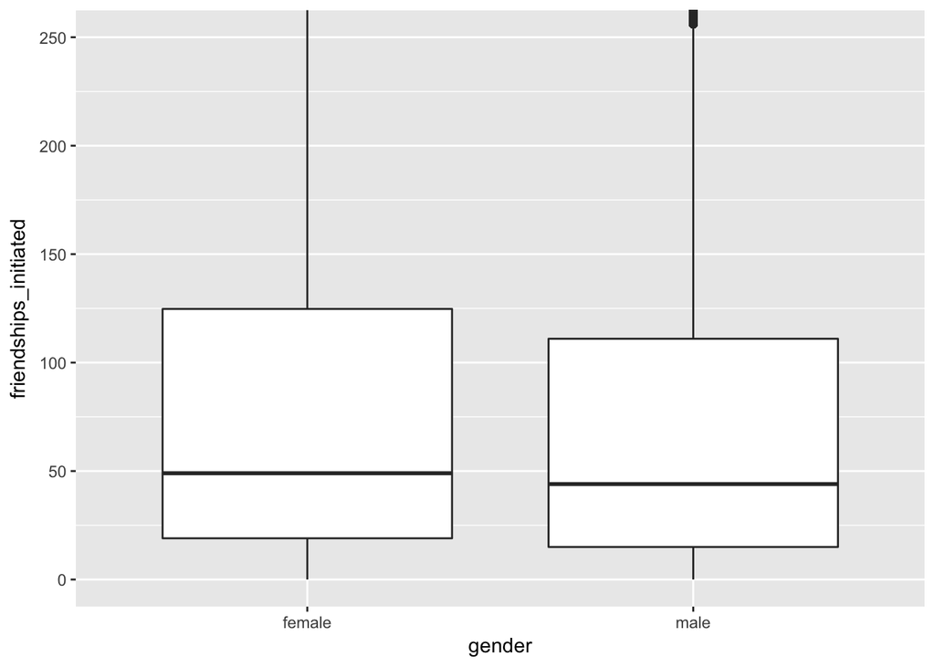

```r
qplot(data= subset(pf,!is.na(gender)),
                   x=gender, y=friendships_initiated, geom='boxplot') +
    coord_cartesian(ylim = c(0,250))
```

```r
by(pf$friendships_initiated, pf$gender, summary)
```

```
## pf$gender: female
##    Min. 1st Qu.  Median    Mean 3rd Qu.    Max.
##     0.0    19.0    49.0   113.9   124.8  3654.0
## --------------------------------------------------------
## pf$gender: male
##    Min. 1st Qu.  Median    Mean 3rd Qu.    Max.
##     0.0    15.0    44.0   103.1   111.0  4144.0
```

Response:

### Getting Logical

Notes:

```r
mobile_check_in <- NA
pf$mobile_check_in <- ifelse(pf$mobile_likes > 0, 1, 0)
pf$mobile_check_in <- factor(pf$mobile_check_in)
summary (pf$mobile_check_in)
```

```
##     0     1
## 35056 63947
```

```r
check_in_pct <-  round(sum(pf$mobile_check_in==1)/length(pf$mobile_check_in) * 100,0)
print (check_in_pct)
```

```
## [1] 65
```

Response:

### Analyzing One Variable

Reflection:

Notes:

distribution, missing values, outliers boxplots, histogram changing the data using log10, sqrt may uncover additional patterns.

Click **KnitHTML** to see all of your hard work and to have an html page of this lesson, your answers, and your notes!